# hw2

ShibeiXu

2021/10/7

## Problem 1

```r
library(tidyverse)
library(readxl)
library(dplyr)
```

### load the trash data with data cleaning

```r
trash_data=read_excel("./data/trash_data.xlsx",sheet = 1,range = cell_cols(1:14))%>%
  janitor::clean_names()%>%
  drop_na(dumpster)%>%
  mutate(sports_balls=round(sports_balls,digits = 0))
head(trash_data,5)
```

```
## # A tibble: 5 x 14
##   dumpster month  year date                weight_tons volume_cubic_yards
##      <dbl> <chr> <dbl> <dttm>                    <dbl>              <dbl>
## 1        1 May    2014 2014-05-16 00:00:00        4.31                 18
## 2        2 May    2014 2014-05-16 00:00:00        2.74                 13
## 3        3 May    2014 2014-05-16 00:00:00        3.45                 15
## 4        4 May    2014 2014-05-17 00:00:00        3.1                  15
## 5        5 May    2014 2014-05-17 00:00:00        4.06                 18
## # ... with 8 more variables: plastic_bottles <dbl>, polystyrene <dbl>,
## #   cigarette_butts <dbl>, glass_bottles <dbl>, grocery_bags <dbl>,
## #   chip_bags <dbl>, sports_balls <dbl>, homes_powered <dbl>
```

### Load the 2018 and 2019 data and combine into one table

```r
prep_2018_data=read_excel("./data/trash_data.xlsx",sheet = 5,skip=1,col_names = TRUE)%>%
  janitor::clean_names()%>%
  drop_na(month)%>%
  mutate(year=2018)
prep_2019_data=read_excel("./data/trash_data.xlsx",sheet = 4,skip=1,col_names = TRUE)%>%
  janitor::clean_names()%>%
  drop_na(month)%>%
  mutate(year=2019)
head(prep_2018_data,5)
```

```
## # A tibble: 5 x 3
##   month total  year
##   <dbl> <dbl> <dbl>
## 1     1  0.94  2018
## 2     2  4.8   2018
## 3     3  2.69  2018
## 4     4  4.69  2018
## 5     5  9.27  2018
```

```r
head(prep_2019_data,5)
```

```
## # A tibble: 5 x 3
##   month total  year
##   <dbl> <dbl> <dbl>
## 1     1  3.1   2019
## 2     2  3.64  2019
## 3     3  4.47  2019
## 4     4  1.46  2019
## 5     5  3.58  2019
```

```r
total_table=bind_rows(prep_2018_data,prep_2019_data)%>%
  mutate(month=month.name[as.numeric(month)])
head(total_table,5)
```

```
## # A tibble: 5 x 3
##   month    total  year
##   <chr>    <dbl> <dbl>
## 1 January   0.94  2018
## 2 February  4.8   2018
## 3 March     2.69  2018
## 4 April     4.69  2018
## 5 May       9.27  2018
```

### Analysis

The combined 2018 and 2019 precipitation data is a [24 x 3] dataset with 3 variables and 24 data input. The variables of this dataset includes month, total, year. The total precipitation in 2018 is 70.33.

The trash table is a [344 x 14] dataser with 14 variable and 344 observations. The variables includes dumpster, month, year, date, weight_tons, volume_cubic_yards, plastic_bottles, polystyrene, cigarette_butts, glass_bottles, grocery_bags, chip_bags, sports_balls, homes_powered. The median number of sports balls in a dumpster in 2019 is 8.5 `

## Problem 2

### clean the data in pols_month

```r
poll_data=read_csv("./data/pols-month.csv")%>%separate("mon",into=c("year","month","date"))%>%mutate(month=month.name[as.numeric(month)],month=str_to_lower(month),president=recode(prez_gop,"0"="dem","1"="gop"))%>%janitor::clean_names()
poll_data=select(poll_data,-date,-prez_dem,-prez_gop)
head(poll_data,5)
```

```
## # A tibble: 5 x 9
##   year  month    gov_gop sen_gop rep_gop gov_dem sen_dem rep_dem president
##   <chr> <chr>      <dbl>   <dbl>   <dbl>   <dbl>   <dbl>   <dbl> <chr>
## 1 1947  january       23      51     253      23      45     198 dem
## 2 1947  february      23      51     253      23      45     198 dem
## 3 1947  march         23      51     253      23      45     198 dem
## 4 1947  april         23      51     253      23      45     198 dem
## 5 1947  may           23      51     253      23      45     198 dem
```

```r
snp=read_csv("data/snp.csv")%>%separate("date",into=c("year","month","day"),sep = "-")%>%mutate(month=month.name[as.numeric(month)],month=str_to_lower(month))%>%janitor::clean_names()
snp=select(snp,-day)
head(snp,5)
```

```
## # A tibble: 5 x 3
##   year  month    close
##   <chr> <chr>    <dbl>
## 1 2007  january  2080.
## 2 2006  january  2063.
## 3 2005  january  2107.
## 4 2004  january  2086.
## 5 2003  february 2068.
```

```r
unemploy=read.csv("./data/unemployment.csv")%>%
  janitor::clean_names()%>%
  pivot_longer(jan:dec,
               names_to = "month",
               values_to = "unemployment rate")%>%
  mutate(year=as.character(year),
    month=recode(month,jan="january",feb="february",mar="march",apr="april",jun="june",jul="july",aug="august",sep="september",oct="october",nov="november",dec="december"))
head(unemploy,5)
```

```
## # A tibble: 5 x 3
##   year  month    `unemployment rate`
##   <chr> <chr>                  <dbl>
## 1 1948  january                  3.4
## 2 1948  february                 3.8
## 3 1948  march                    4
## 4 1948  april                    3.9
## 5 1948  may                      3.5
```

```r
poll_1_data=left_join(poll_data,snp)
poll_full=left_join(poll_1_data,unemploy)
head(poll_full,5)
```

```
## # A tibble: 5 x 11
##   year  month    gov_gop sen_gop rep_gop gov_dem sen_dem rep_dem president close
##   <chr> <chr>      <dbl>   <dbl>   <dbl>   <dbl>   <dbl>   <dbl> <chr>     <dbl>
## 1 1947  january       23      51     253      23      45     198 dem          NA
## 2 1947  february      23      51     253      23      45     198 dem          NA
## 3 1947  march         23      51     253      23      45     198 dem          NA
## 4 1947  april         23      51     253      23      45     198 dem          NA
## 5 1947  may           23      51     253      23      45     198 dem          NA
## # ... with 1 more variable: unemployment rate <dbl>
```

The combined poll,snp and unemployment data is a [960 x 11] dataset with 11 variables and 960 data input. The variables of this dataset includes year, month, gov_gop, sen_gop, rep_gop, gov_dem, sen_dem, rep_dem, president, close, unemployment rate. The total range of the year included in this data is 1947, 2015.

## Problem 3

```r
baby_data=read_csv("./data/baby_name.csv")%>%
  janitor::clean_names()%>%
  mutate(
    childs_first_name=str_to_lower(childs_first_name),
    ethnicity=str_to_lower(ethnicity),
    gender=str_to_lower(gender),
    ethnicity=recode(ethnicity,"asian and paci"="asian and pacific islander","black non hisp"="black non hispanic","white non hisp"="white non hispanic"))%>%
    distinct()
head(baby_data,5)
```

```
## # A tibble: 5 x 6
##   year_of_birth gender ethnicity                  childs_first_name count  rank
##           <dbl> <chr>  <chr>                      <chr>             <dbl> <dbl>
## 1          2016 female asian and pacific islander olivia              172     1
## 2          2016 female asian and pacific islander chloe               112     2
## 3          2016 female asian and pacific islander sophia              104     3
## 4          2016 female asian and pacific islander emily                99     4
## 5          2016 female asian and pacific islander emma                 99     4
```

### produce the table for the rank of the name olivia

```r
olivia_table=filter(baby_data,childs_first_name=="olivia")%>%
  select(-gender,-childs_first_name,-count)%>%
  mutate(year_of_birth=as.factor(year_of_birth))
head(olivia_table,5)
```

```
## # A tibble: 5 x 3
##   year_of_birth ethnicity                   rank
##   <fct>         <chr>                      <dbl>
## 1 2016          asian and pacific islander     1
## 2 2016          black non hispanic             8
## 3 2016          hispanic                      13
## 4 2016          white non hispanic             1
## 5 2015          asian and pacific islander     1
```

### pivot the year into columns

```r
pivot_wider(olivia_table,names_from = year_of_birth,values_from = rank)
```

```
## # A tibble: 4 x 7
##   ethnicity                  `2016` `2015` `2014` `2013` `2012` `2011`
##   <chr>                       <dbl>  <dbl>  <dbl>  <dbl>  <dbl>  <dbl>
## 1 asian and pacific islander      1      1      1      3      3      4
## 2 black non hispanic              8      4      8      6      8     10
## 3 hispanic                       13     16     16     22     22     18
## 4 white non hispanic              1      1      1      1      4      2
```

### find the most popular name over time among male children

```r
male_table=filter(baby_data,rank==1&gender=="male")%>%
select(-gender,-count,-rank)%>%
  mutate(year_of_birth=as.factor(year_of_birth))
head(male_table,5)
```

```
## # A tibble: 5 x 3
##   year_of_birth ethnicity                  childs_first_name
##   <fct>         <chr>                      <chr>
## 1 2016          asian and pacific islander ethan
## 2 2016          black non hispanic         noah
## 3 2016          hispanic                   liam
## 4 2016          white non hispanic         joseph
## 5 2015          asian and pacific islander jayden
```

### Pivot the year into columns

```r
pivot_wider(male_table,names_from = year_of_birth,values_from = childs_first_name)
```

```
## # A tibble: 4 x 7
##   ethnicity                  `2016` `2015` `2014` `2013` `2012` `2011`
##   <chr>                      <chr>  <chr>  <chr>  <chr>  <chr>  <chr>
## 1 asian and pacific islander ethan  jayden jayden jayden ryan   ethan
## 2 black non hispanic         noah   noah   ethan  ethan  jayden jayden
## 3 hispanic                   liam   liam   liam   jayden jayden jayden
## 4 white non hispanic         joseph david  joseph david  joseph michael
```

### produce a scatter plot showing the number of children with a name (y axis) against the rank in popularity of that name (x axis) for male, white non-hispanic children born in 2016

```r
graph_data=filter(baby_data,gender=="male"&year_of_birth==2016&ethnicity=="white non hispanic")
```

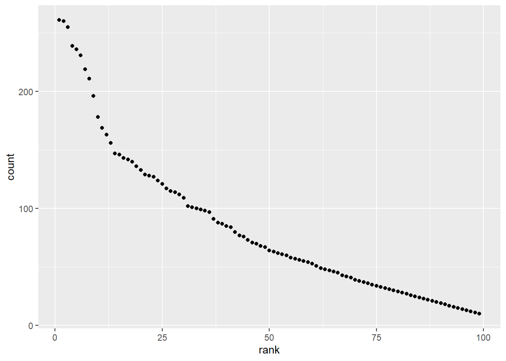

```r
ggplot(graph_data,aes(x=rank,y=count))+geom_point()
```